# Using Raster Data in R

## 8.2 Visual Summaries

The `raster` package provides many functions to visualy display and summarise the data in `Raster*` objects. The `rasterVis` package complements the `raster` package, providing additional methods for enhanced visualization and interaction.

Some of the functions in this packages can only be used in single-layer rasters, others can only be used in muti-layered rasters, and the remaining functions can be used for both single-layer and multi-layer rasters. In particular, the visualisation functions that we explore below can be applied the the following raster data types:

- Single-layer raster objects:
  - In `raster` packge: `contour`
- Single-layer & multi-layer raster objects:
  - In `raster` packge: `histogram`, `densityplot`, `persp`
  - In `rasterVis` packge: `contourplot`
- Multi-layer raster objects:
  - In `raster` packge: `pairs`, `plotRGB`
  - In `rasterVis` packge: `bwplot`

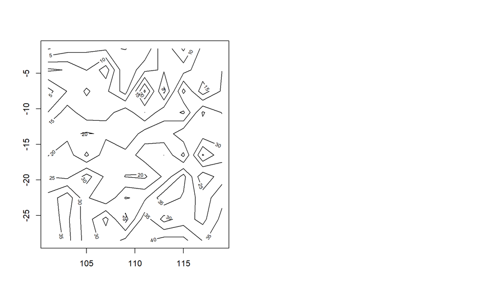

```r
# In package 'raster'
# ==================
# In addition of 'plot()' to draw the values of a raster (see above)


# For a Single Layer objects exclusively
# --------------------------------------
# Contour: Contour plot of a Raster Layer
par(mfrow=c(1,2))
contour(r2b)
#contour(s2)   # WRONG: It doesn't work! ('contourplot()' in 'rasterVis' pkg works for all Raster* objects)


# For both a Single Layer and Multiple Layers objects
# ---------------------------------------------------

# Histogram: Draw histograms (with lattice) of Raster objects.
par(mfrow=c(1,2))
```

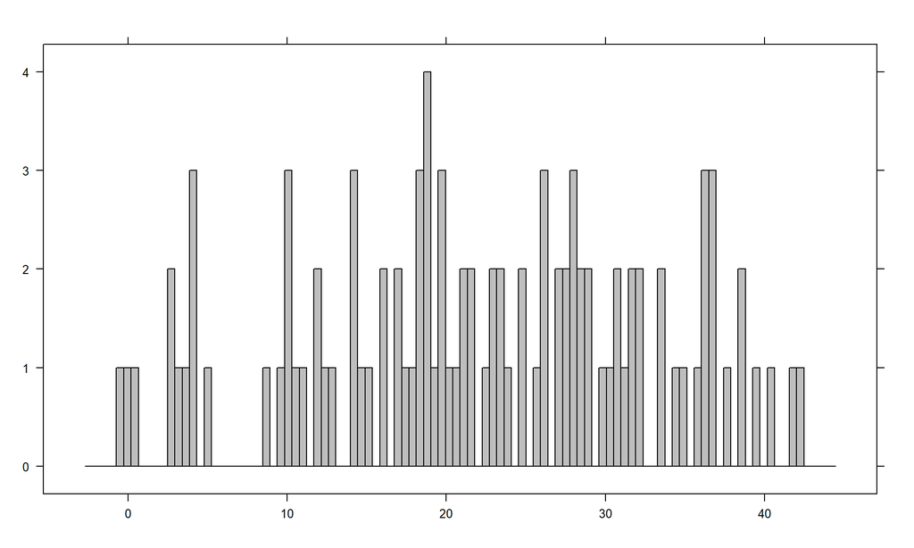

```r
histogram(r2b)
```

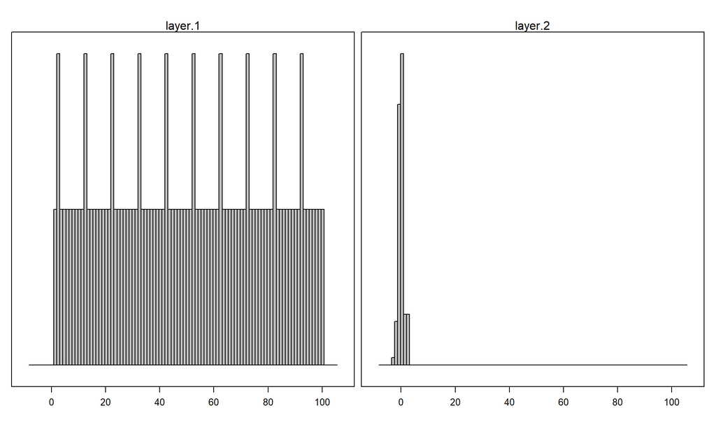

```r
histogram(s2)
```

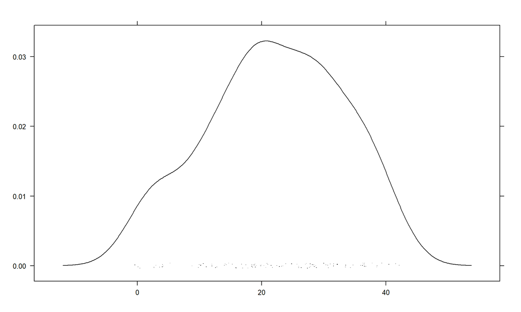

```r
# Density plots: Draw kernel density plots (with lattice) of Raster objects.
# par(mfrow=c(1,2)) # 'par()': Doesn't work with 'densityplot()'
densityplot(r2b)
```

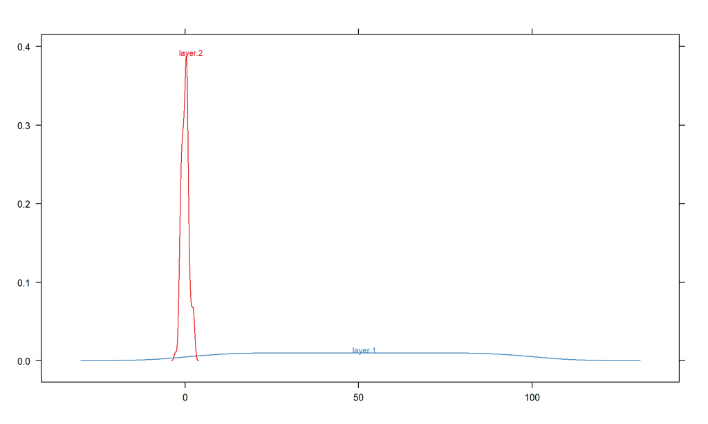

```r
densityplot(s2)
```

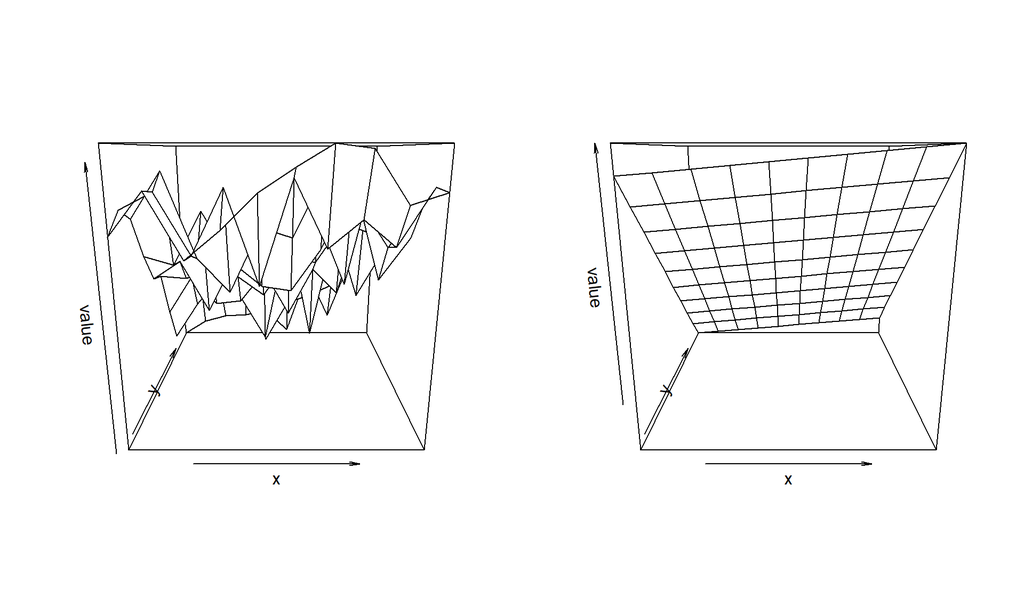

```r
# Perspective plot. This is an implementation of a generic function in the graphics package.
par(mfrow=c(1,2))
persp(r2b)
persp(s2)
```

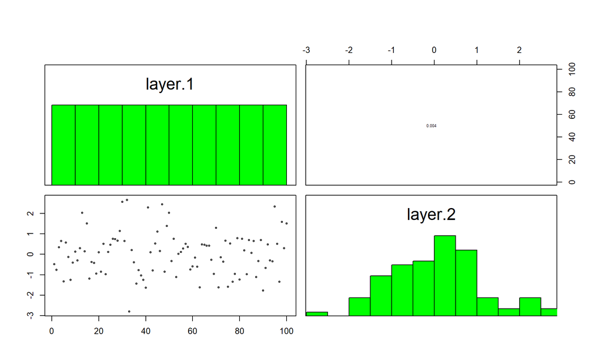

```r
# For a Multiple Layers (RasterStack and RasterBrick objects) objects exclusively
# -------------------------------------------------------------------------------
# Pairs: Pair plots of layers in a RasterStack or RasterBrick.
# This is a wrapper around graphics function pairs.
par(mfrow=c(1,1))
pairs(s2)
```

[figure not shown]

```r
# plotRGB: Make a Red-Green-Blue plot based on 3 layers. (Description and Example from 'plotRGB()' Help).
# These 3 layers are sometimes referred to as "bands" because they may represent different bandwidths in the
# electromagnetic spectrum.
# The 3 layers are combined such that they represent the red, green and blue channel.
# This function can be used to make 'true (or false) color images' from Landsat and other multi-band satellite images.
b = brick(system.file("external/rlogo.grd", package="raster"))
plotRGB(b)
```

[figure not shown]

```r
plotRGB(b, 3, 2, 1)
```

[figure not shown]

```r
plotRGB(b, 3, 2, 1, stretch='hist')
```

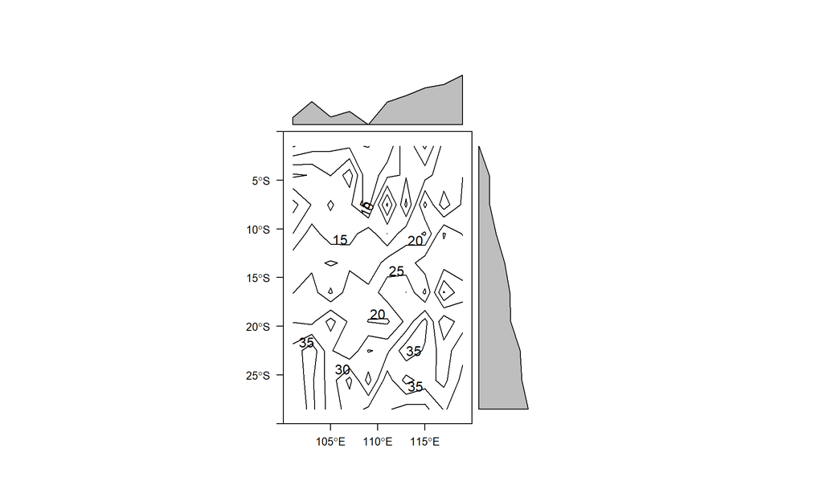

```r
rm(b)



# In package 'rasterVis'
# ======================
# In addition of 'levelplot()' to draw the values of a raster (see above)



# For both a Single Layer and Multiple Layers objects
# ---------------------------------------------------
# Contour Plots of Raster objects with lattice methods and marginal plots with grid objects.
contourplot(r2b)
```

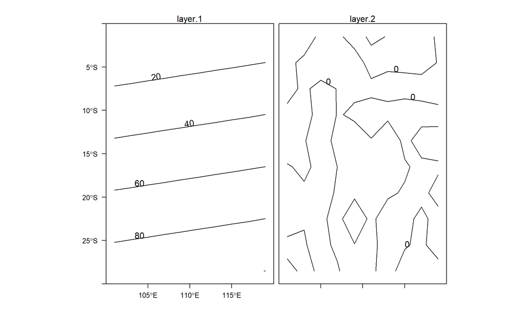

```r
contourplot(s2)
```

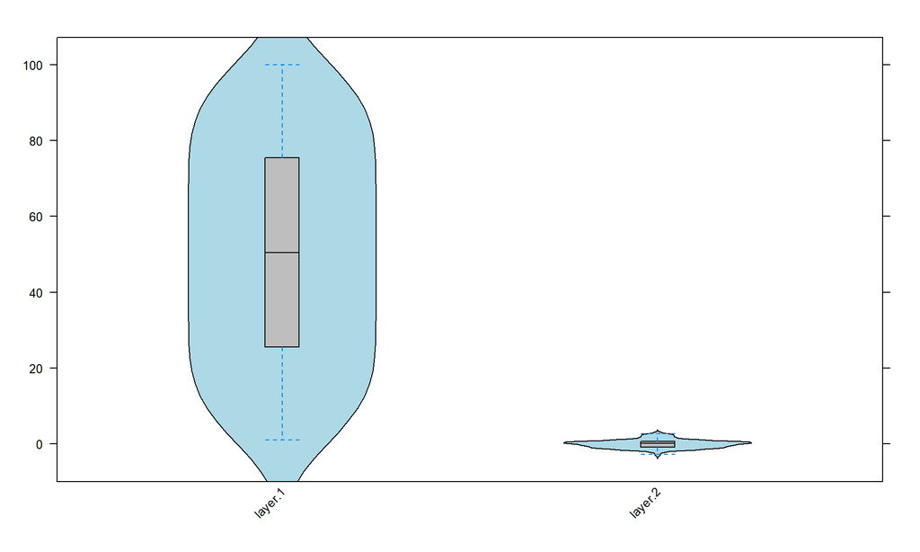

```r
# For Multiple Layers (RasterStack and RasterBrick objects) object exclusively
# ----------------------------------------------------------------------------
# Bwplots: Plots of RasterStackBrick objects using to compose the graphic a combination of:
#  panel.violin and panel.bwplot.
bwplot(s2)
```

# 9 Working with rasters values

## 9.1 Modifying individual cell values

```r
# Directly (already used above to assing values to raster r2b)
r1c = r1b
r1c[5,1:5] = 6:10  # (In row 5, columns 1 to 5 = 6 to 10)
values(r1c)
```

```
##   [1]  2  2  2  2  2  2  2  2  2  2  2  2  2  2  2  2  2  2  2  2  2  2  2
##  [24]  2  2  2  2  2  2  2  2  2  2  2  2  2  2  2  2  2  2  2  2  2  2  2
##  [47]  2  2  2  2  2  2  2  2  2  2  2  2  2  2  6  7  8  9 10  2  2  2  2
##  [70]  2  2  2  2  2  2  2  2  2  2  2  2  2  2  2  2  2  2  2  2  2  2  2
##  [93]  2  2  2  2  2  2  2  2  2  2  2  2  2  2  2  2  2  2  2  2  2  2  2
## [116]  2  2  2  2  2  2  2  2  2  2  2  2  2  2  2  2  2  2  2  2  2  2  2
## [139]  2  2  2  2  2  2  2  2  2  2  2  2
```

```r
r1c[5,6]=NA   # Missing data
values(r1c)
```

```
##   [1]  2  2  2  2  2  2  2  2  2  2  2  2  2  2  2  2  2  2  2  2  2  2  2
##  [24]  2  2  2  2  2  2  2  2  2  2  2  2  2  2  2  2  2  2  2  2  2  2  2
##  [47]  2  2  2  2  2  2  2  2  2  2  2  2  2  2  6  7  8  9 10 NA  2  2  2
##  [70]  2  2  2  2  2  2  2  2  2  2  2  2  2  2  2  2  2  2  2  2  2  2  2
##  [93]  2  2  2  2  2  2  2  2  2  2  2  2  2  2  2  2  2  2  2  2  2  2  2
## [116]  2  2  2  2  2  2  2  2  2  2  2  2  2  2  2  2  2  2  2  2  2  2  2
## [139]  2  2  2  2  2  2  2  2  2  2  2  2
```

```r
r1c[5,6]=-9999    # '-9999' is the Missing Data Flag in many GIS standards (e.g. NEON)
values(r1c)
```

```
##   [1]     2     2     2     2     2     2     2     2     2     2     2
##  [12]     2     2     2     2     2     2     2     2     2     2     2
##  [23]     2     2     2     2     2     2     2     2     2     2     2
##  [34]     2     2     2     2     2     2     2     2     2     2     2
##  [45]     2     2     2     2     2     2     2     2     2     2     2
##  [56]     2     2     2     2     2     6     7     8     9    10 -9999
##  [67]     2     2     2     2     2     2     2     2     2     2     2
##  [78]     2     2     2     2     2     2     2     2     2     2     2
##  [89]     2     2     2     2     2     2     2     2     2     2     2
## [100]     2     2     2     2     2     2     2     2     2     2     2
## [111]     2     2     2     2     2     2     2     2     2     2     2
## [122]     2     2     2     2     2     2     2     2     2     2     2
## [133]     2     2     2     2     2     2     2     2     2     2     2
## [144]     2     2     2     2     2     2     2
```

```r
# Combined with replacement functions
values(r1c)   # Missing data flag: -9999
```

```
##   [1]     2     2     2     2     2     2     2     2     2     2     2
##  [12]     2     2     2     2     2     2     2     2     2     2     2
##  [23]     2     2     2     2     2     2     2     2     2     2     2
##  [34]     2     2     2     2     2     2     2     2     2     2     2
##  [45]     2     2     2     2     2     2     2     2     2     2     2
##  [56]     2     2     2     2     2     6     7     8     9    10 -9999
##  [67]     2     2     2     2     2     2     2     2     2     2     2
##  [78]     2     2     2     2     2     2     2     2     2     2     2
##  [89]     2     2     2     2     2     2     2     2     2     2     2
## [100]     2     2     2     2     2     2     2     2     2     2     2
## [111]     2     2     2     2     2     2     2     2     2     2     2
## [122]     2     2     2     2     2     2     2     2     2     2     2
## [133]     2     2     2     2     2     2     2     2     2     2     2
## [144]     2     2     2     2     2     2     2
```

```r
r1c[r1c==-9999] = NA  # Missing data flag changed back to: NA
values(r1c)
```

```
##   [1]  2  2  2  2  2  2  2  2  2  2  2  2  2  2  2  2  2  2  2  2  2  2  2
##  [24]  2  2  2  2  2  2  2  2  2  2  2  2  2  2  2  2  2  2  2  2  2  2  2
##  [47]  2  2  2  2  2  2  2  2  2  2  2  2  2  2  6  7  8  9 10 NA  2  2  2
##  [70]  2  2  2  2  2  2  2  2  2  2  2  2  2  2  2  2  2  2  2  2  2  2  2
##  [93]  2  2  2  2  2  2  2  2  2  2  2  2  2  2  2  2  2  2  2  2  2  2  2
## [116]  2  2  2  2  2  2  2  2  2  2  2  2  2  2  2  2  2  2  2  2  2  2  2
## [139]  2  2  2  2  2  2  2  2  2  2  2  2
```

```r
r1c = (r1c==2)
values(r1c)
```

```
##   [1]  TRUE  TRUE  TRUE  TRUE  TRUE  TRUE  TRUE  TRUE  TRUE  TRUE  TRUE
##  [12]  TRUE  TRUE  TRUE  TRUE  TRUE  TRUE  TRUE  TRUE  TRUE  TRUE  TRUE
##  [23]  TRUE  TRUE  TRUE  TRUE  TRUE  TRUE  TRUE  TRUE  TRUE  TRUE  TRUE
##  [34]  TRUE  TRUE  TRUE  TRUE  TRUE  TRUE  TRUE  TRUE  TRUE  TRUE  TRUE
##  [45]  TRUE  TRUE  TRUE  TRUE  TRUE  TRUE  TRUE  TRUE  TRUE  TRUE  TRUE
##  [56]  TRUE  TRUE  TRUE  TRUE  TRUE FALSE FALSE FALSE FALSE FALSE    NA
##  [67]  TRUE  TRUE  TRUE  TRUE  TRUE  TRUE  TRUE  TRUE  TRUE  TRUE  TRUE
##  [78]  TRUE  TRUE  TRUE  TRUE  TRUE  TRUE  TRUE  TRUE  TRUE  TRUE  TRUE
##  [89]  TRUE  TRUE  TRUE  TRUE  TRUE  TRUE  TRUE  TRUE  TRUE  TRUE  TRUE
## [100]  TRUE  TRUE  TRUE  TRUE  TRUE  TRUE  TRUE  TRUE  TRUE  TRUE  TRUE
## [111]  TRUE  TRUE  TRUE  TRUE  TRUE  TRUE  TRUE  TRUE  TRUE  TRUE  TRUE
## [122]  TRUE  TRUE  TRUE  TRUE  TRUE  TRUE  TRUE  TRUE  TRUE  TRUE  TRUE
## [133]  TRUE  TRUE  TRUE  TRUE  TRUE  TRUE  TRUE  TRUE  TRUE  TRUE  TRUE
## [144]  TRUE  TRUE  TRUE  TRUE  TRUE  TRUE  TRUE
```

```r
r1c[!r1c] = 0
r1c[r1c] = 1
values(r1c)
```

```
##   [1]  1  1  1  1  1  1  1  1  1  1  1  1  1  1  1  1  1  1  1  1  1  1  1
##  [24]  1  1  1  1  1  1  1  1  1  1  1  1  1  1  1  1  1  1  1  1  1  1  1
##  [47]  1  1  1  1  1  1  1  1  1  1  1  1  1  1  0  0  0  0  0 NA  1  1  1
##  [70]  1  1  1  1  1  1  1  1  1  1  1  1  1  1  1  1  1  1  1  1  1  1  1
##  [93]  1  1  1  1  1  1  1  1  1  1  1  1  1  1  1  1  1  1  1  1  1  1  1
## [116]  1  1  1  1  1  1  1  1  1  1  1  1  1  1  1  1  1  1  1  1  1  1  1
## [139]  1  1  1  1  1  1  1  1  1  1  1  1
```

## 9.2 Raster Calculations

### 9.2.1 ‘Raster Algebra’ (also known as ‘Raster Maths’)

Used for small rasters and simple calculations

Directly combines rasters using:

- Operators (for more information on R Operators see this [link](https://www.datamentor.io/r-programming/operator/)):
  - Arithmetic operators (+,’-,*,/,^,%%,%/%)
  - Relational operators (>, <, >=, <=, ==, !=)
  - Logical operators (!,&,&&,|,||)
- Functions (algebraic (but ‘abs’), summary, and logical functions need > 1 layer):
  - Algebraic functions (e.g. abs, sum, prod)
  - Rounding functions (round, ceiling, floor, trunc)
  - Re-scaling functions (e.g. log, log10, sqrt, exp)
  - Trigonometric functions (e.g. sin, cos, tan, atan)
  - Summary functions (e.g. min, max, range)
  - Logical functions(any, all)

```r
# Using 1 layer
# --------------
values(r1a)
```

```
##   [1] 1 1 1 1 1 1 1 1 1 1 1 1 1 1 1 1 1 1 1 1 1 1 1 1 1 1 1 1 1 1 1 1 1 1 1
##  [36] 1 1 1 1 1 1 1 1 1 1 1 1 1 1 1 1 1 1 1 1 1 1 1 1 1 1 1 1 1 1 1 1 1 1 1
##  [71] 1 1 1 1 1 1 1 1 1 1 1 1 1 1 1 1 1 1 1 1 1 1 1 1 1 1 1 1 1 1 1 1 1 1 1
## [106] 1 1 1 1 1 1 1 1 1 1 1 1 1 1 1 1 1 1 1 1 1 1 1 1 1 1 1 1 1 1 1 1 1 1 1
## [141] 1 1 1 1 1 1 1 1 1 1
```

```r
values((r1a * 3)^2)
```

```
##   [1] 9 9 9 9 9 9 9 9 9 9 9 9 9 9 9 9 9 9 9 9 9 9 9 9 9 9 9 9 9 9 9 9 9 9 9
##  [36] 9 9 9 9 9 9 9 9 9 9 9 9 9 9 9 9 9 9 9 9 9 9 9 9 9 9 9 9 9 9 9 9 9 9 9
##  [71] 9 9 9 9 9 9 9 9 9 9 9 9 9 9 9 9 9 9 9 9 9 9 9 9 9 9 9 9 9 9 9 9 9 9 9
## [106] 9 9 9 9 9 9 9 9 9 9 9 9 9 9 9 9 9 9 9 9 9 9 9 9 9 9 9 9 9 9 9 9 9 9 9
## [141] 9 9 9 9 9 9 9 9 9 9
```

```r
values(r1a == 1)
```

```
##   [1] TRUE TRUE TRUE TRUE TRUE TRUE TRUE TRUE TRUE TRUE TRUE TRUE TRUE TRUE
##  [15] TRUE TRUE TRUE TRUE TRUE TRUE TRUE TRUE TRUE TRUE TRUE TRUE TRUE TRUE
##  [29] TRUE TRUE TRUE TRUE TRUE TRUE TRUE TRUE TRUE TRUE TRUE TRUE TRUE TRUE
##  [43] TRUE TRUE TRUE TRUE TRUE TRUE TRUE TRUE TRUE TRUE TRUE TRUE TRUE TRUE
##  [57] TRUE TRUE TRUE TRUE TRUE TRUE TRUE TRUE TRUE TRUE TRUE TRUE TRUE TRUE
##  [71] TRUE TRUE TRUE TRUE TRUE TRUE TRUE TRUE TRUE TRUE TRUE TRUE TRUE TRUE
##  [85] TRUE TRUE TRUE TRUE TRUE TRUE TRUE TRUE TRUE TRUE TRUE TRUE TRUE TRUE
##  [99] TRUE TRUE TRUE TRUE TRUE TRUE TRUE TRUE TRUE TRUE TRUE TRUE TRUE TRUE
## [113] TRUE TRUE TRUE TRUE TRUE TRUE TRUE TRUE TRUE TRUE TRUE TRUE TRUE TRUE
## [127] TRUE TRUE TRUE TRUE TRUE TRUE TRUE TRUE TRUE TRUE TRUE TRUE TRUE TRUE
## [141] TRUE TRUE TRUE TRUE TRUE TRUE TRUE TRUE TRUE TRUE
```

```r
values(!(r1a == 1))
```

```
##   [1] FALSE FALSE FALSE FALSE FALSE FALSE FALSE FALSE FALSE FALSE FALSE
##  [12] FALSE FALSE FALSE FALSE FALSE FALSE FALSE FALSE FALSE FALSE FALSE
##  [23] FALSE FALSE FALSE FALSE FALSE FALSE FALSE FALSE FALSE FALSE FALSE
##  [34] FALSE FALSE FALSE FALSE FALSE FALSE FALSE FALSE FALSE FALSE FALSE
##  [45] FALSE FALSE FALSE FALSE FALSE FALSE FALSE FALSE FALSE FALSE FALSE
##  [56] FALSE FALSE FALSE FALSE FALSE FALSE FALSE FALSE FALSE FALSE FALSE
##  [67] FALSE FALSE FALSE FALSE FALSE FALSE FALSE FALSE FALSE FALSE FALSE
##  [78] FALSE FALSE FALSE FALSE FALSE FALSE FALSE FALSE FALSE FALSE FALSE
##  [89] FALSE FALSE FALSE FALSE FALSE FALSE FALSE FALSE FALSE FALSE FALSE
## [100] FALSE FALSE FALSE FALSE FALSE FALSE FALSE FALSE FALSE FALSE FALSE
## [111] FALSE FALSE FALSE FALSE FALSE FALSE FALSE FALSE FALSE FALSE FALSE
## [122] FALSE FALSE FALSE FALSE FALSE FALSE FALSE FALSE FALSE FALSE FALSE
## [133] FALSE FALSE FALSE FALSE FALSE FALSE FALSE FALSE FALSE FALSE FALSE
## [144] FALSE FALSE FALSE FALSE FALSE FALSE FALSE
```

```r
values(sqrt(r1b))
```

```
##   [1] 1.414214 1.414214 1.414214 1.414214 1.414214 1.414214 1.414214
##   [8] 1.414214 1.414214 1.414214 1.414214 1.414214 1.414214 1.414214
##  [15] 1.414214 1.414214 1.414214 1.414214 1.414214 1.414214 1.414214
##  [22] 1.414214 1.414214 1.414214 1.414214 1.414214 1.414214 1.414214
##  [29] 1.414214 1.414214 1.414214 1.414214 1.414214 1.414214 1.414214
##  [36] 1.414214 1.414214 1.414214 1.414214 1.414214 1.414214 1.414214
##  [43] 1.414214 1.414214 1.414214 1.414214 1.414214 1.414214 1.414214
##  [50] 1.414214 1.414214 1.414214 1.414214 1.414214 1.414214 1.414214
##  [57] 1.414214 1.414214 1.414214 1.414214 1.414214 1.414214 1.414214
##  [64] 1.414214 1.414214 1.414214 1.414214 1.414214 1.414214 1.414214
##  [71] 1.414214 1.414214 1.414214 1.414214 1.414214 1.414214 1.414214
##  [78] 1.414214 1.414214 1.414214 1.414214 1.414214 1.414214 1.414214
##  [85] 1.414214 1.414214 1.414214 1.414214 1.414214 1.414214 1.414214
##  [92] 1.414214 1.414214 1.414214 1.414214 1.414214 1.414214 1.414214
##  [99] 1.414214 1.414214 1.414214 1.414214 1.414214 1.414214 1.414214
## [106] 1.414214 1.414214 1.414214 1.414214 1.414214 1.414214 1.414214
## [113] 1.414214 1.414214 1.414214 1.414214 1.414214 1.414214 1.414214
## [120] 1.414214 1.414214 1.414214 1.414214 1.414214 1.414214 1.414214
## [127] 1.414214 1.414214 1.414214 1.414214 1.414214 1.414214 1.414214
## [134] 1.414214 1.414214 1.414214 1.414214 1.414214 1.414214 1.414214
## [141] 1.414214 1.414214 1.414214 1.414214 1.414214 1.414214 1.414214
## [148] 1.414214 1.414214 1.414214
```

```r
values(round(sqrt(r1b)))
```

```
##   [1] 1 1 1 1 1 1 1 1 1 1 1 1 1 1 1 1 1 1 1 1 1 1 1 1 1 1 1 1 1 1 1 1 1 1 1
##  [36] 1 1 1 1 1 1 1 1 1 1 1 1 1 1 1 1 1 1 1 1 1 1 1 1 1 1 1 1 1 1 1 1 1 1 1
##  [71] 1 1 1 1 1 1 1 1 1 1 1 1 1 1 1 1 1 1 1 1 1 1 1 1 1 1 1 1 1 1 1 1 1 1 1
## [106] 1 1 1 1 1 1 1 1 1 1 1 1 1 1 1 1 1 1 1 1 1 1 1 1 1 1 1 1 1 1 1 1 1 1 1
## [141] 1 1 1 1 1 1 1 1 1 1
```

```r
values(round(sqrt(r1b))==1)
```

```
##   [1] TRUE TRUE TRUE TRUE TRUE TRUE TRUE TRUE TRUE TRUE TRUE TRUE TRUE TRUE
##  [15] TRUE TRUE TRUE TRUE TRUE TRUE TRUE TRUE TRUE TRUE TRUE TRUE TRUE TRUE
##  [29] TRUE TRUE TRUE TRUE TRUE TRUE TRUE TRUE TRUE TRUE TRUE TRUE TRUE TRUE
##  [43] TRUE TRUE TRUE TRUE TRUE TRUE TRUE TRUE TRUE TRUE TRUE TRUE TRUE TRUE
##  [57] TRUE TRUE TRUE TRUE TRUE TRUE TRUE TRUE TRUE TRUE TRUE TRUE TRUE TRUE
##  [71] TRUE TRUE TRUE TRUE TRUE TRUE TRUE TRUE TRUE TRUE TRUE TRUE TRUE TRUE
##  [85] TRUE TRUE TRUE TRUE TRUE TRUE TRUE TRUE TRUE TRUE TRUE TRUE TRUE TRUE
##  [99] TRUE TRUE TRUE TRUE TRUE TRUE TRUE TRUE TRUE TRUE TRUE TRUE TRUE TRUE
## [113] TRUE TRUE TRUE TRUE TRUE TRUE TRUE TRUE TRUE TRUE TRUE TRUE TRUE TRUE
## [127] TRUE TRUE TRUE TRUE TRUE TRUE TRUE TRUE TRUE TRUE TRUE TRUE TRUE TRUE
## [141] TRUE TRUE TRUE TRUE TRUE TRUE TRUE TRUE TRUE TRUE
```

```r
# Using multiple layers
# -----------------------

# With Operatros
values(r1a)
```

```
##   [1] 1 1 1 1 1 1 1 1 1 1 1 1 1 1 1 1 1 1 1 1 1 1 1 1 1 1 1 1 1 1 1 1 1 1 1
##  [36] 1 1 1 1 1 1 1 1 1 1 1 1 1 1 1 1 1 1 1 1 1 1 1 1 1 1 1 1 1 1 1 1 1 1 1
##  [71] 1 1 1 1 1 1 1 1 1 1 1 1 1 1 1 1 1 1 1 1 1 1 1 1 1 1 1 1 1 1 1 1 1 1 1
## [106] 1 1 1 1 1 1 1 1 1 1 1 1 1 1 1 1 1 1 1 1 1 1 1 1 1 1 1 1 1 1 1 1 1 1 1
## [141] 1 1 1 1 1 1 1 1 1 1
```

```r
values(r1b)
```

```
##   [1] 2 2 2 2 2 2 2 2 2 2 2 2 2 2 2 2 2 2 2 2 2 2 2 2 2 2 2 2 2 2 2 2 2 2 2
##  [36] 2 2 2 2 2 2 2 2 2 2 2 2 2 2 2 2 2 2 2 2 2 2 2 2 2 2 2 2 2 2 2 2 2 2 2
##  [71] 2 2 2 2 2 2 2 2 2 2 2 2 2 2 2 2 2 2 2 2 2 2 2 2 2 2 2 2 2 2 2 2 2 2 2
## [106] 2 2 2 2 2 2 2 2 2 2 2 2 2 2 2 2 2 2 2 2 2 2 2 2 2 2 2 2 2 2 2 2 2 2 2
## [141] 2 2 2 2 2 2 2 2 2 2
```

```r
r1c=r1a + r1b
values(r1c)
```

```
##   [1] 3 3 3 3 3 3 3 3 3 3 3 3 3 3 3 3 3 3 3 3 3 3 3 3 3 3 3 3 3 3 3 3 3 3 3
##  [36] 3 3 3 3 3 3 3 3 3 3 3 3 3 3 3 3 3 3 3 3 3 3 3 3 3 3 3 3 3 3 3 3 3 3 3
##  [71] 3 3 3 3 3 3 3 3 3 3 3 3 3 3 3 3 3 3 3 3 3 3 3 3 3 3 3 3 3 3 3 3 3 3 3
## [106] 3 3 3 3 3 3 3 3 3 3 3 3 3 3 3 3 3 3 3 3 3 3 3 3 3 3 3 3 3 3 3 3 3 3 3
## [141] 3 3 3 3 3 3 3 3 3 3
```

```r
# With Functions
  # Algebraic functions
values(sum(r1a,r1b))
```

```
##   [1] 3 3 3 3 3 3 3 3 3 3 3 3 3 3 3 3 3 3 3 3 3 3 3 3 3 3 3 3 3 3 3 3 3 3 3
##  [36] 3 3 3 3 3 3 3 3 3 3 3 3 3 3 3 3 3 3 3 3 3 3 3 3 3 3 3 3 3 3 3 3 3 3 3
##  [71] 3 3 3 3 3 3 3 3 3 3 3 3 3 3 3 3 3 3 3 3 3 3 3 3 3 3 3 3 3 3 3 3 3 3 3
## [106] 3 3 3 3 3 3 3 3 3 3 3 3 3 3 3 3 3 3 3 3 3 3 3 3 3 3 3 3 3 3 3 3 3 3 3
## [141] 3 3 3 3 3 3 3 3 3 3
```

```r
values(prod(r1a,r1b))
```

```
##   [1] 2 2 2 2 2 2 2 2 2 2 2 2 2 2 2 2 2 2 2 2 2 2 2 2 2 2 2 2 2 2 2 2 2 2 2
##  [36] 2 2 2 2 2 2 2 2 2 2 2 2 2 2 2 2 2 2 2 2 2 2 2 2 2 2 2 2 2 2 2 2 2 2 2
##  [71] 2 2 2 2 2 2 2 2 2 2 2 2 2 2 2 2 2 2 2 2 2 2 2 2 2 2 2 2 2 2 2 2 2 2 2
## [106] 2 2 2 2 2 2 2 2 2 2 2 2 2 2 2 2 2 2 2 2 2 2 2 2 2 2 2 2 2 2 2 2 2 2 2
## [141] 2 2 2 2 2 2 2 2 2 2
```

```r
  # Summary functions
values(max(r1a,r1b))
```

```
##   [1] 2 2 2 2 2 2 2 2 2 2 2 2 2 2 2 2 2 2 2 2 2 2 2 2 2 2 2 2 2 2 2 2 2 2 2
##  [36] 2 2 2 2 2 2 2 2 2 2 2 2 2 2 2 2 2 2 2 2 2 2 2 2 2 2 2 2 2 2 2 2 2 2 2
##  [71] 2 2 2 2 2 2 2 2 2 2 2 2 2 2 2 2 2 2 2 2 2 2 2 2 2 2 2 2 2 2 2 2 2 2 2
## [106] 2 2 2 2 2 2 2 2 2 2 2 2 2 2 2 2 2 2 2 2 2 2 2 2 2 2 2 2 2 2 2 2 2 2 2
## [141] 2 2 2 2 2 2 2 2 2 2
```

```r
values(min(r1a,r1b))
```

```
##   [1] 1 1 1 1 1 1 1 1 1 1 1 1 1 1 1 1 1 1 1 1 1 1 1 1 1 1 1 1 1 1 1 1 1 1 1
##  [36] 1 1 1 1 1 1 1 1 1 1 1 1 1 1 1 1 1 1 1 1 1 1 1 1 1 1 1 1 1 1 1 1 1 1 1
##  [71] 1 1 1 1 1 1 1 1 1 1 1 1 1 1 1 1 1 1 1 1 1 1 1 1 1 1 1 1 1 1 1 1 1 1 1
## [106] 1 1 1 1 1 1 1 1 1 1 1 1 1 1 1 1 1 1 1 1 1 1 1 1 1 1 1 1 1 1 1 1 1 1 1
## [141] 1 1 1 1 1 1 1 1 1 1
```

```r
values(mean(r1a,r1b))
```

```
##   [1] 1.5 1.5 1.5 1.5 1.5 1.5 1.5 1.5 1.5 1.5 1.5 1.5 1.5 1.5 1.5 1.5 1.5
##  [18] 1.5 1.5 1.5 1.5 1.5 1.5 1.5 1.5 1.5 1.5 1.5 1.5 1.5 1.5 1.5 1.5 1.5
##  [35] 1.5 1.5 1.5 1.5 1.5 1.5 1.5 1.5 1.5 1.5 1.5 1.5 1.5 1.5 1.5 1.5 1.5
##  [52] 1.5 1.5 1.5 1.5 1.5 1.5 1.5 1.5 1.5 1.5 1.5 1.5 1.5 1.5 1.5 1.5 1.5
##  [69] 1.5 1.5 1.5 1.5 1.5 1.5 1.5 1.5 1.5 1.5 1.5 1.5 1.5 1.5 1.5 1.5 1.5
##  [86] 1.5 1.5 1.5 1.5 1.5 1.5 1.5 1.5 1.5 1.5 1.5 1.5 1.5 1.5 1.5 1.5 1.5
## [103] 1.5 1.5 1.5 1.5 1.5 1.5 1.5 1.5 1.5 1.5 1.5 1.5 1.5 1.5 1.5 1.5 1.5
## [120] 1.5 1.5 1.5 1.5 1.5 1.5 1.5 1.5 1.5 1.5 1.5 1.5 1.5 1.5 1.5 1.5 1.5
## [137] 1.5 1.5 1.5 1.5 1.5 1.5 1.5 1.5 1.5 1.5 1.5 1.5 1.5 1.5
```

```r
  # Logical Functions
values(r1c)
```

```
##   [1] 3 3 3 3 3 3 3 3 3 3 3 3 3 3 3 3 3 3 3 3 3 3 3 3 3 3 3 3 3 3 3 3 3 3 3
##  [36] 3 3 3 3 3 3 3 3 3 3 3 3 3 3 3 3 3 3 3 3 3 3 3 3 3 3 3 3 3 3 3 3 3 3 3
##  [71] 3 3 3 3 3 3 3 3 3 3 3 3 3 3 3 3 3 3 3 3 3 3 3 3 3 3 3 3 3 3 3 3 3 3 3
## [106] 3 3 3 3 3 3 3 3 3 3 3 3 3 3 3 3 3 3 3 3 3 3 3 3 3 3 3 3 3 3 3 3 3 3 3
## [141] 3 3 3 3 3 3 3 3 3 3
```

```r
r1c = (r1c == 1)
values(r1c)
```

```
##   [1] FALSE FALSE FALSE FALSE FALSE FALSE FALSE FALSE FALSE FALSE FALSE
##  [12] FALSE FALSE FALSE FALSE FALSE FALSE FALSE FALSE FALSE FALSE FALSE
##  [23] FALSE FALSE FALSE FALSE FALSE FALSE FALSE FALSE FALSE FALSE FALSE
##  [34] FALSE FALSE FALSE FALSE FALSE FALSE FALSE FALSE FALSE FALSE FALSE
##  [45] FALSE FALSE FALSE FALSE FALSE FALSE FALSE FALSE FALSE FALSE FALSE
##  [56] FALSE FALSE FALSE FALSE FALSE FALSE FALSE FALSE FALSE FALSE FALSE
##  [67] FALSE FALSE FALSE FALSE FALSE FALSE FALSE FALSE FALSE FALSE FALSE
##  [78] FALSE FALSE FALSE FALSE FALSE FALSE FALSE FALSE FALSE FALSE FALSE
##  [89] FALSE FALSE FALSE FALSE FALSE FALSE FALSE FALSE FALSE FALSE FALSE
## [100] FALSE FALSE FALSE FALSE FALSE FALSE FALSE FALSE FALSE FALSE FALSE
## [111] FALSE FALSE FALSE FALSE FALSE FALSE FALSE FALSE FALSE FALSE FALSE
## [122] FALSE FALSE FALSE FALSE FALSE FALSE FALSE FALSE FALSE FALSE FALSE
## [133] FALSE FALSE FALSE FALSE FALSE FALSE FALSE FALSE FALSE FALSE FALSE
## [144] FALSE FALSE FALSE FALSE FALSE FALSE FALSE
```

```r
values(any(r1c, !r1c))
```

```
##   [1] TRUE TRUE TRUE TRUE TRUE TRUE TRUE TRUE TRUE TRUE TRUE TRUE TRUE TRUE
##  [15] TRUE TRUE TRUE TRUE TRUE TRUE TRUE TRUE TRUE TRUE TRUE TRUE TRUE TRUE
##  [29] TRUE TRUE TRUE TRUE TRUE TRUE TRUE TRUE TRUE TRUE TRUE TRUE TRUE TRUE
##  [43] TRUE TRUE TRUE TRUE TRUE TRUE TRUE TRUE TRUE TRUE TRUE TRUE TRUE TRUE
##  [57] TRUE TRUE TRUE TRUE TRUE TRUE TRUE TRUE TRUE TRUE TRUE TRUE TRUE TRUE
##  [71] TRUE TRUE TRUE TRUE TRUE TRUE TRUE TRUE TRUE TRUE TRUE TRUE TRUE TRUE
##  [85] TRUE TRUE TRUE TRUE TRUE TRUE TRUE TRUE TRUE TRUE TRUE TRUE TRUE TRUE
##  [99] TRUE TRUE TRUE TRUE TRUE TRUE TRUE TRUE TRUE TRUE TRUE TRUE TRUE TRUE
## [113] TRUE TRUE TRUE TRUE TRUE TRUE TRUE TRUE TRUE TRUE TRUE TRUE TRUE TRUE
## [127] TRUE TRUE TRUE TRUE TRUE TRUE TRUE TRUE TRUE TRUE TRUE TRUE TRUE TRUE
## [141] TRUE TRUE TRUE TRUE TRUE TRUE TRUE TRUE TRUE TRUE
```

```r
values(all(r1c, !r1c))
```

```
##   [1] FALSE FALSE FALSE FALSE FALSE FALSE FALSE FALSE FALSE FALSE FALSE
##  [12] FALSE FALSE FALSE FALSE FALSE FALSE FALSE FALSE FALSE FALSE FALSE
##  [23] FALSE FALSE FALSE FALSE FALSE FALSE FALSE FALSE FALSE FALSE FALSE
##  [34] FALSE FALSE FALSE FALSE FALSE FALSE FALSE FALSE FALSE FALSE FALSE
##  [45] FALSE FALSE FALSE FALSE FALSE FALSE FALSE FALSE FALSE FALSE FALSE
##  [56] FALSE FALSE FALSE FALSE FALSE FALSE FALSE FALSE FALSE FALSE FALSE
##  [67] FALSE FALSE FALSE FALSE FALSE FALSE FALSE FALSE FALSE FALSE FALSE
##  [78] FALSE FALSE FALSE FALSE FALSE FALSE FALSE FALSE FALSE FALSE FALSE
##  [89] FALSE FALSE FALSE FALSE FALSE FALSE FALSE FALSE FALSE FALSE FALSE
## [100] FALSE FALSE FALSE FALSE FALSE FALSE FALSE FALSE FALSE FALSE FALSE
## [111] FALSE FALSE FALSE FALSE FALSE FALSE FALSE FALSE FALSE FALSE FALSE
## [122] FALSE FALSE FALSE FALSE FALSE FALSE FALSE FALSE FALSE FALSE FALSE
## [133] FALSE FALSE FALSE FALSE FALSE FALSE FALSE FALSE FALSE FALSE FALSE
## [144] FALSE FALSE FALSE FALSE FALSE FALSE FALSE
```

### 9.2.2 Raster Calculations using Higher Level Functions

Directly adding, subtracting, etc. layers of big raster objects is not recommended.

For big raster objects High Level Functions should be used instead.

#### 9.2.2.1 For a Single Raster Objects

`calc`: Uses a single Raster* object and a provided formula to calculate values for a new Raster* object.

The function type will depend of the input object type: * For a uni-layer (RasterLayer) input, the function is typically a function that can take a single vector as input and return a vector of values of the same length (e.g. sqrt). * For a multi-layer (RasterStack or RasterBrick) input, the function should operate on a vector of values, with one vector for each cell.

The object type returned depends on the input object type and function type: * When input is a RasterLayer, it returns a RasterLayer. * When input is a RasterStack or RasterBrick and the Function a Summary type Function (i.e. returns a single value), it returns a RasterLayer. * When input is a RasterStack or RasterBrick and the Function returns more than one number (e.g. fun=quantile), it returns a a RasterBrick.

In many cases, what can be achieved with ‘calc’, can also be accomplished with a more intuitive ‘raster-algebra’ notation. For example, the log10 of the cells in a raster can be computed as log10(r), which is simpler than using calc with this function. However, `calc` should be faster when using large datasets and/or complex formulas.

The function can even be a statistical function, such as `lm`. See `cacl` help for details.

```r
# To calculate the log10 of the values in a raster can do:
 # Method 1: Directly providing the function
r1b.log10.m1 = calc(r1b, fun=log10)
r1b.log10.m1
```

```
## class       : RasterLayer
## dimensions  : 10, 15, 150  (nrow, ncol, ncell)
## resolution  : 24, 18  (x, y)
## extent      : -180, 180, -90, 90  (xmin, xmax, ymin, ymax)
## coord. ref. : +proj=longlat +datum=WGS84 +ellps=WGS84 +towgs84=0,0,0
## data source : in memory
## names       : layer
## values      : 0.30103, 0.30103  (min, max)
```

```r
 # Method 2: Writing a function and passing it on.
r1b.log10.m2 = function(r) { log10(r) }
r1b.log10.m2 = calc(r1b, fun=r1b.log10.m2)
r1b.log10.m2
```

```
## class       : RasterLayer
## dimensions  : 10, 15, 150  (nrow, ncol, ncell)
## resolution  : 24, 18  (x, y)
## extent      : -180, 180, -90, 90  (xmin, xmax, ymin, ymax)
## coord. ref. : +proj=longlat +datum=WGS84 +ellps=WGS84 +towgs84=0,0,0
## data source : in memory
## names       : layer
## values      : 0.30103, 0.30103  (min, max)
```

```r
# Replace values too high (>100) and too low (< 0) with NAs
r5 = raster(ncols=10, nrows=10)
r5[] = runif(ncell(r5), min=-10, max=110)
summary(r5)
```

```
##              layer
## Min.     -9.111708
## 1st Qu.  23.091168
## Median   50.212433
## 3rd Qu.  75.402430
## Max.    109.874840
## NA's      0.000000
```

```r
replacement.f1 = function(r) { r[r<0|r>100] = NA; return(r) }
r5.NAs = calc(r5, fun=replacement.f1)
summary(r5.NAs)
```

```
##             layer
## Min.     2.139685
## 1st Qu. 24.356284
## Median  50.330578
## 3rd Qu. 68.495652
## Max.    95.574670
## NA's    17.000000
```

```r
# Replace 'NA' with '-9999', the code for missing values in some package
 replacement.f2 = function(r) { r[is.na(r)] = -9999; return(r) }
 r5.neg9999 = calc(r5.NAs, fun=replacement.f2)
 summary(r5.neg9999)
```

```
##               layer
## Min.    -9999.00000
## 1st Qu.    20.07953
## Median     41.02053
## 3rd Qu.    65.30502
## Max.       95.57467
## NA's        0.00000
```

`stackApply`: Computes summary type layers for subsets of a RasterStack or RasterBrick. To do so it uses a summary function applied on subsets of layers of a RasterStack or RasterBrick object.These subsets are defined by vector indices. If the number of indeces in the vector is smaller than the number of layers the indices are recycled. The summary function must return a single value; thus, the number of layers in the output Raster* equals then number of unique values in the indices vector. If the output raster contains a single layer it would be a RasterLayer object. If it contains multiple layers it would be a RasterBrick object.

```r
# it would be a RasterBrick object.
s = stack(r1a,r1a,r1a,r1b,r1b,r1b)

s.sA1 = stackApply(s, indices=rep(1,nlayers(s)), fun=mean)
s.sA1
```

```
## class       : RasterLayer
## dimensions  : 10, 15, 150  (nrow, ncol, ncell)
## resolution  : 24, 18  (x, y)
## extent      : -180, 180, -90, 90  (xmin, xmax, ymin, ymax)
## coord. ref. : +proj=longlat +datum=WGS84 +ellps=WGS84 +towgs84=0,0,0
## data source : in memory
## names       : index_1
## values      : 1.5, 1.5  (min, max)
```

```r
# Providing indices for all layers. Output is a RasterBrick with 2 layers: Mean of layers 1-3 and mean of layers 4-6.
s.sA2 = stackApply(s, indices=c(1,1,1,2,2,2), fun=mean)
s.sA2
```

```
## class       : RasterBrick
## dimensions  : 10, 15, 150, 2  (nrow, ncol, ncell, nlayers)
## resolution  : 24, 18  (x, y)
## extent      : -180, 180, -90, 90  (xmin, xmax, ymin, ymax)
## coord. ref. : +proj=longlat +datum=WGS84 +ellps=WGS84 +towgs84=0,0,0
## data source : in memory
## names       : index_1, index_2
## min values  :       1,       2
## max values  :       1,       2
```

```r
# Recycled indices. Output is a RasterBrick with 2 layers: Mean of layers 1, 3,and 5 and mean of layers 2, 4, and 6.
s.sA3 = stackApply(s, indices=c(1,2), fun=mean)
s.sA3
```

```
## class       : RasterBrick
## dimensions  : 10, 15, 150, 2  (nrow, ncol, ncell, nlayers)
## resolution  : 24, 18  (x, y)
## extent      : -180, 180, -90, 90  (xmin, xmax, ymin, ymax)
## coord. ref. : +proj=longlat +datum=WGS84 +ellps=WGS84 +towgs84=0,0,0
## data source : in memory
## names       :  index_1,  index_2
## min values  : 1.333333, 1.666667
## max values  : 1.333333, 1.666667
```

```r
rm(s)
```

`overlay`: It is typically used with multiple Raster* objects, but it can also be used with a single `Raster*` object. However, it is often simpler to use `calc` (or “Raster Algebra”) for single Raster* objects. See next section for its application to multi-layered raster objects.

#### 9.2.2.2 For a Multiple Raster Objects

`ovelay`: It is more efficient that ‘Raster Maths’ when rasters are large and/or calculations complex and/or rasters stored in separate individual files.

NOTE: Do not confuse with the deprecated ‘overlay’ function in the ‘sp’ package. They are different.

Syntax: output.ras = overlay(input1.ras, input2.ras, fun=FunctionCalcName)

The raster objects used as inputs can be single-layered or multi-layered rasters (with the same number of layers). Both case produce similar results. In the multi-layered rasters case the function is applied to each pair of layers.

```r
# Input single-layered objects (RasterLayer)
# ..........................................
values(r1a)
```

```
##   [1] 1 1 1 1 1 1 1 1 1 1 1 1 1 1 1 1 1 1 1 1 1 1 1 1 1 1 1 1 1 1 1 1 1 1 1
##  [36] 1 1 1 1 1 1 1 1 1 1 1 1 1 1 1 1 1 1 1 1 1 1 1 1 1 1 1 1 1 1 1 1 1 1 1
##  [71] 1 1 1 1 1 1 1 1 1 1 1 1 1 1 1 1 1 1 1 1 1 1 1 1 1 1 1 1 1 1 1 1 1 1 1
## [106] 1 1 1 1 1 1 1 1 1 1 1 1 1 1 1 1 1 1 1 1 1 1 1 1 1 1 1 1 1 1 1 1 1 1 1
## [141] 1 1 1 1 1 1 1 1 1 1
```

```r
values(r1b)
```

```
##   [1] 2 2 2 2 2 2 2 2 2 2 2 2 2 2 2 2 2 2 2 2 2 2 2 2 2 2 2 2 2 2 2 2 2 2 2
##  [36] 2 2 2 2 2 2 2 2 2 2 2 2 2 2 2 2 2 2 2 2 2 2 2 2 2 2 2 2 2 2 2 2 2 2 2
##  [71] 2 2 2 2 2 2 2 2 2 2 2 2 2 2 2 2 2 2 2 2 2 2 2 2 2 2 2 2 2 2 2 2 2 2 2
## [106] 2 2 2 2 2 2 2 2 2 2 2 2 2 2 2 2 2 2 2 2 2 2 2 2 2 2 2 2 2 2 2 2 2 2 2
## [141] 2 2 2 2 2 2 2 2 2 2
```

```r
# Adding Rasters
 # Using Raster Algebra with Operators
r1c=r1a + r1b
values(r1c)
```

```
##   [1] 3 3 3 3 3 3 3 3 3 3 3 3 3 3 3 3 3 3 3 3 3 3 3 3 3 3 3 3 3 3 3 3 3 3 3
##  [36] 3 3 3 3 3 3 3 3 3 3 3 3 3 3 3 3 3 3 3 3 3 3 3 3 3 3 3 3 3 3 3 3 3 3 3
##  [71] 3 3 3 3 3 3 3 3 3 3 3 3 3 3 3 3 3 3 3 3 3 3 3 3 3 3 3 3 3 3 3 3 3 3 3
## [106] 3 3 3 3 3 3 3 3 3 3 3 3 3 3 3 3 3 3 3 3 3 3 3 3 3 3 3 3 3 3 3 3 3 3 3
## [141] 3 3 3 3 3 3 3 3 3 3
```

```r
 # Using 'overlay()'
r1d = overlay( r1a, r1b, fun=function(r1,r2) {return(r1+r2)} )
values(r1d)
```

```
##   [1] 3 3 3 3 3 3 3 3 3 3 3 3 3 3 3 3 3 3 3 3 3 3 3 3 3 3 3 3 3 3 3 3 3 3 3
##  [36] 3 3 3 3 3 3 3 3 3 3 3 3 3 3 3 3 3 3 3 3 3 3 3 3 3 3 3 3 3 3 3 3 3 3 3
##  [71] 3 3 3 3 3 3 3 3 3 3 3 3 3 3 3 3 3 3 3 3 3 3 3 3 3 3 3 3 3 3 3 3 3 3 3
## [106] 3 3 3 3 3 3 3 3 3 3 3 3 3 3 3 3 3 3 3 3 3 3 3 3 3 3 3 3 3 3 3 3 3 3 3
## [141] 3 3 3 3 3 3 3 3 3 3
```

```r
values(r1c==r1d)  # Compare individual cells, are they equal?
```

```
##   [1] TRUE TRUE TRUE TRUE TRUE TRUE TRUE TRUE TRUE TRUE TRUE TRUE TRUE TRUE
##  [15] TRUE TRUE TRUE TRUE TRUE TRUE TRUE TRUE TRUE TRUE TRUE TRUE TRUE TRUE
##  [29] TRUE TRUE TRUE TRUE TRUE TRUE TRUE TRUE TRUE TRUE TRUE TRUE TRUE TRUE
##  [43] TRUE TRUE TRUE TRUE TRUE TRUE TRUE TRUE TRUE TRUE TRUE TRUE TRUE TRUE
##  [57] TRUE TRUE TRUE TRUE TRUE TRUE TRUE TRUE TRUE TRUE TRUE TRUE TRUE TRUE
##  [71] TRUE TRUE TRUE TRUE TRUE TRUE TRUE TRUE TRUE TRUE TRUE TRUE TRUE TRUE
##  [85] TRUE TRUE TRUE TRUE TRUE TRUE TRUE TRUE TRUE TRUE TRUE TRUE TRUE TRUE
##  [99] TRUE TRUE TRUE TRUE TRUE TRUE TRUE TRUE TRUE TRUE TRUE TRUE TRUE TRUE
## [113] TRUE TRUE TRUE TRUE TRUE TRUE TRUE TRUE TRUE TRUE TRUE TRUE TRUE TRUE
## [127] TRUE TRUE TRUE TRUE TRUE TRUE TRUE TRUE TRUE TRUE TRUE TRUE TRUE TRUE
## [141] TRUE TRUE TRUE TRUE TRUE TRUE TRUE TRUE TRUE TRUE
```

```r
all(values(r1c==r1d))  # Are all cells equal (in 1 answer)?
```

```
## [1] TRUE
```

```r
# Using a function
silly.f = function(x,y) {
                silly.ras = x* round((y)^(2/3))
                return(silly.ras)
                }
r1e = overlay(r1a, r1b, fun=silly.f)
values(r1e)
```

```
##   [1] 2 2 2 2 2 2 2 2 2 2 2 2 2 2 2 2 2 2 2 2 2 2 2 2 2 2 2 2 2 2 2 2 2 2 2
##  [36] 2 2 2 2 2 2 2 2 2 2 2 2 2 2 2 2 2 2 2 2 2 2 2 2 2 2 2 2 2 2 2 2 2 2 2
##  [71] 2 2 2 2 2 2 2 2 2 2 2 2 2 2 2 2 2 2 2 2 2 2 2 2 2 2 2 2 2 2 2 2 2 2 2
## [106] 2 2 2 2 2 2 2 2 2 2 2 2 2 2 2 2 2 2 2 2 2 2 2 2 2 2 2 2 2 2 2 2 2 2 2
## [141] 2 2 2 2 2 2 2 2 2 2
```

```r
# Input multi-layered objects (RasterStack/RasterBrick)
# .....................................................
s1a = stack(r1a,r1a)
s1b = stack(r1b,r1b)
s1ab = stack(r1a,r1b)
s1a; s1b
```

```
## class       : RasterStack
## dimensions  : 10, 15, 150, 2  (nrow, ncol, ncell, nlayers)
## resolution  : 24, 18  (x, y)
## extent      : -180, 180, -90, 90  (xmin, xmax, ymin, ymax)
## coord. ref. : +proj=longlat +datum=WGS84 +ellps=WGS84 +towgs84=0,0,0
## names       : layer.1, layer.2
## min values  :       1,       1
## max values  :       1,       1
```

```
## class       : RasterStack
## dimensions  : 10, 15, 150, 2  (nrow, ncol, ncell, nlayers)
## resolution  : 24, 18  (x, y)
## extent      : -180, 180, -90, 90  (xmin, xmax, ymin, ymax)
## coord. ref. : +proj=longlat +datum=WGS84 +ellps=WGS84 +towgs84=0,0,0
## names       : layer.1, layer.2
## min values  :       2,       2
## max values  :       2,       2
```

```r
# Adding rasters
s1d1 = overlay( s1a, s1b, fun=function(r1,r2) {return(r1+r2)} )
s1d2 = overlay( s1ab, s1ab, fun=function(r1,r2) {return(r1+r2)} )
r1d; s1d1; s1d2
```

```
## class       : RasterLayer
## dimensions  : 10, 15, 150  (nrow, ncol, ncell)
## resolution  : 24, 18  (x, y)
## extent      : -180, 180, -90, 90  (xmin, xmax, ymin, ymax)
## coord. ref. : +proj=longlat +datum=WGS84 +ellps=WGS84 +towgs84=0,0,0
## data source : in memory
## names       : layer
## values      : 3, 3  (min, max)
```

```
## class       : RasterBrick
## dimensions  : 10, 15, 150, 2  (nrow, ncol, ncell, nlayers)
## resolution  : 24, 18  (x, y)
## extent      : -180, 180, -90, 90  (xmin, xmax, ymin, ymax)
## coord. ref. : +proj=longlat +datum=WGS84 +ellps=WGS84 +towgs84=0,0,0
## data source : in memory
## names       : layer.1, layer.2
## min values  :       3,       3
## max values  :       3,       3
```

```
## class       : RasterBrick
## dimensions  : 10, 15, 150, 2  (nrow, ncol, ncell, nlayers)
## resolution  : 24, 18  (x, y)
## extent      : -180, 180, -90, 90  (xmin, xmax, ymin, ymax)
## coord. ref. : +proj=longlat +datum=WGS84 +ellps=WGS84 +towgs84=0,0,0
## data source : in memory
## names       : layer.1, layer.2
## min values  :       2,       4
## max values  :       2,       4
```

```r
# Using a function
s1e1 = overlay(s1a, s1b, fun=silly.f)
s1e2 = overlay(s1ab, s1ab, fun=silly.f)
r1e; s1e1; s1e2
```

```
## class       : RasterLayer
## dimensions  : 10, 15, 150  (nrow, ncol, ncell)
## resolution  : 24, 18  (x, y)
## extent      : -180, 180, -90, 90  (xmin, xmax, ymin, ymax)
## coord. ref. : +proj=longlat +datum=WGS84 +ellps=WGS84 +towgs84=0,0,0
## data source : in memory
## names       : layer
## values      : 2, 2  (min, max)
```

```
## class       : RasterBrick
## dimensions  : 10, 15, 150, 2  (nrow, ncol, ncell, nlayers)
## resolution  : 24, 18  (x, y)
## extent      : -180, 180, -90, 90  (xmin, xmax, ymin, ymax)
## coord. ref. : +proj=longlat +datum=WGS84 +ellps=WGS84 +towgs84=0,0,0
## data source : in memory
## names       : layer.1, layer.2
## min values  :       2,       2
## max values  :       2,       2
```

```
## class       : RasterBrick
## dimensions  : 10, 15, 150, 2  (nrow, ncol, ncell, nlayers)
## resolution  : 24, 18  (x, y)
## extent      : -180, 180, -90, 90  (xmin, xmax, ymin, ymax)
## coord. ref. : +proj=longlat +datum=WGS84 +ellps=WGS84 +towgs84=0,0,0
## data source : in memory
## names       : layer.1, layer.2
## min values  :       1,       4
## max values  :       1,       4
```

```r
rm(r1d, r1e, s1d1, s1d2, s1e1, s1e2)
```

NOTE: Rasters in operations including multiple rasters must have the same: Dimensions, Projection, Extent, and Resolution. E.g.: Create a new raster with the same Dimensions and Projection than r1a and r1b, but different Extent and Resolution

```r
r3 = raster(nrow=10, ncol=15, xmn=100, xmx=130, ymn=-30, ymx=0)
values(r3) = 5;
r1a; r1b; r3
```

```
## class       : RasterLayer
## dimensions  : 10, 15, 150  (nrow, ncol, ncell)
## resolution  : 24, 18  (x, y)
## extent      : -180, 180, -90, 90  (xmin, xmax, ymin, ymax)
## coord. ref. : +proj=longlat +datum=WGS84 +ellps=WGS84 +towgs84=0,0,0
## data source : in memory
## names       : layer
## values      : 1, 1  (min, max)
```

```
## class       : RasterLayer
## dimensions  : 10, 15, 150  (nrow, ncol, ncell)
## resolution  : 24, 18  (x, y)
## extent      : -180, 180, -90, 90  (xmin, xmax, ymin, ymax)
## coord. ref. : +proj=longlat +datum=WGS84 +ellps=WGS84 +towgs84=0,0,0
## data source : in memory
## names       : layer
## values      : 2, 2  (min, max)
```

```
## class       : RasterLayer
## dimensions  : 10, 15, 150  (nrow, ncol, ncell)
## resolution  : 2, 3  (x, y)
## extent      : 100, 130, -30, 0  (xmin, xmax, ymin, ymax)
## coord. ref. : +proj=longlat +datum=WGS84 +ellps=WGS84 +towgs84=0,0,0
## data source : in memory
## names       : layer
## values      : 5, 5  (min, max)
```

```r
values(r1a+r1b)   # Works
```

```
##   [1] 3 3 3 3 3 3 3 3 3 3 3 3 3 3 3 3 3 3 3 3 3 3 3 3 3 3 3 3 3 3 3 3 3 3 3
##  [36] 3 3 3 3 3 3 3 3 3 3 3 3 3 3 3 3 3 3 3 3 3 3 3 3 3 3 3 3 3 3 3 3 3 3 3
##  [71] 3 3 3 3 3 3 3 3 3 3 3 3 3 3 3 3 3 3 3 3 3 3 3 3 3 3 3 3 3 3 3 3 3 3 3
## [106] 3 3 3 3 3 3 3 3 3 3 3 3 3 3 3 3 3 3 3 3 3 3 3 3 3 3 3 3 3 3 3 3 3 3 3
## [141] 3 3 3 3 3 3 3 3 3 3
```

```r
#values(r1a+r3)     # Does Not Work
rm(r3)
```

## 9.3 Raster Classification

Aim: To reclassify values in the raster; for example from 6 different land-types, ecosystems to 3

```r
r3 = raster(nrow=10, ncol=10)
values(r3) = sample(x=1:6, size=ncell(r3), replace=TRUE)
values(r3)
```

```
##   [1] 1 2 3 3 3 6 6 5 2 1 4 4 5 3 2 2 2 6 1 1 2 1 1 3 1 6 5 2 1 5 3 1 5 3 1
##  [36] 1 5 5 4 5 2 3 5 3 3 6 6 6 1 5 5 5 4 1 5 1 5 6 6 6 1 3 2 4 2 3 2 2 6 2
##  [71] 2 3 4 5 4 2 6 2 4 5 4 3 3 6 4 3 1 1 4 3 1 2 6 6 2 2 4 2 2 4
```

```r
old.vals = sort(unique(values(r3)))
old.vals
```

```
## [1] 1 2 3 4 5 6
```

```r
reclass.m = matrix(c(old.vals, c(1,rep(2,3),3,3)), ncol=2)
reclass.m
```

```
##      [,1] [,2]
## [1,]    1    1
## [2,]    2    2
## [3,]    3    2
## [4,]    4    2
## [5,]    5    3
## [6,]    6    3
```

```r
r3.reclass = reclassify(r3, rcl=reclass.m)
values(r3)
```

```
##   [1] 1 2 3 3 3 6 6 5 2 1 4 4 5 3 2 2 2 6 1 1 2 1 1 3 1 6 5 2 1 5 3 1 5 3 1
##  [36] 1 5 5 4 5 2 3 5 3 3 6 6 6 1 5 5 5 4 1 5 1 5 6 6 6 1 3 2 4 2 3 2 2 6 2
##  [71] 2 3 4 5 4 2 6 2 4 5 4 3 3 6 4 3 1 1 4 3 1 2 6 6 2 2 4 2 2 4
```

```r
values(r3.reclass)
```

```
##   [1] 1 2 2 2 2 3 3 3 2 1 2 2 3 2 2 2 2 3 1 1 2 1 1 2 1 3 3 2 1 3 2 1 3 2 1
##  [36] 1 3 3 2 3 2 2 3 2 2 3 3 3 1 3 3 3 2 1 3 1 3 3 3 3 1 2 2 2 2 2 2 2 3 2
##  [71] 2 2 2 3 2 2 3 2 2 3 2 2 2 3 2 2 1 1 2 2 1 2 3 3 2 2 2 2 2 2
```

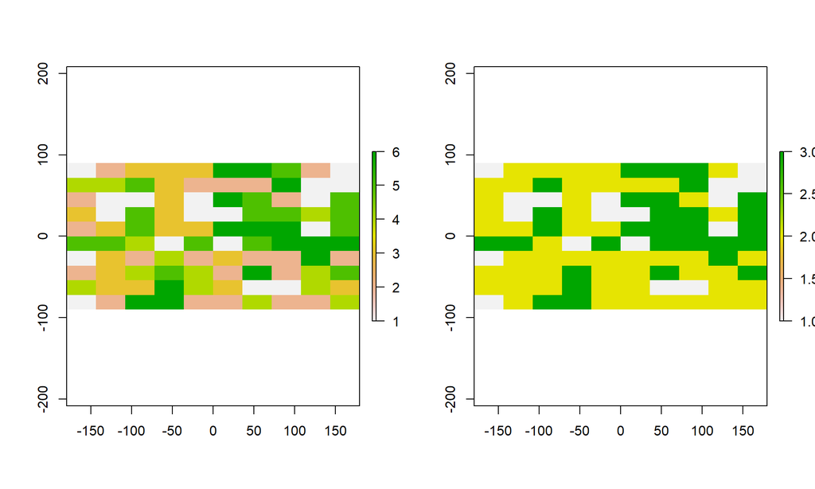

```r
par(mfrow=c(1,2))
plot(r3)
plot(r3.reclass)
```

# 10 Other ways to Combine multiple Raster objects: ‘mask()’ and ‘cover()’

## 10.1 ‘mask()’

`mask()`: It creates a new Raster* object that has the same values as x, except for the cells that are NA (or other maskvalue) in a ‘mask’. These cells become NA (or other updatevalue). The mask can be: A Raster* object of the same extent and resolution, or a Spatial* object (e.g. SpatialPolygons) in which case all cells that are not covered by the Spatial object are set to updatevalue. You can use `inverse=TRUE` to set the cells that are not NA (or other maskvalue) in the mask, or not covered by the Spatial* object, to NA (or other updatevalue).

```r
# Exlore Original Raster
r2b; r2b[]
```

```
## class       : RasterLayer
## dimensions  : 10, 10, 100  (nrow, ncol, ncell)
## resolution  : 2, 3  (x, y)
## extent      : 100, 120, -30, 0  (xmin, xmax, ymin, ymax)
## coord. ref. : +proj=longlat +datum=WGS84 +ellps=WGS84 +towgs84=0,0,0
## data source : in memory
## names       : layer
## values      : -0.3952436, 42.14388  (min, max)
```

```
##   [1] -0.39524360  2.66384294  3.99954580  4.16745679  5.24988026
##   [6]  0.40589315 14.30651973  4.04091835 16.92986168 16.77818836
##  [11] 15.88233646 14.68644886  9.80848040 17.79975006  0.09885152
##  [16]  8.78180736 10.60200546 12.80048936 18.42631733 19.93899239
##  [21]  2.98455584 10.21879499 15.83377606 11.08843678  2.67961229
##  [26] 25.97203594  3.56009869 26.38698756 12.01518560 20.87927482
##  [31] 10.14196183 17.46669274 11.99108315 12.56389331 18.43483351
##  [36]  9.93879763 18.98364432 14.12359146 30.63319358 24.77790145
##  [41] 18.92852131 18.54557685 20.67532531 18.84050075 15.27813125
##  [46] 22.45902285 21.52867981 28.72469832 27.04850185 28.48428457
##  [51] 19.80453669 22.88693760 14.00985039 23.21223542 21.75694613
##  [56] 27.83304516 30.00598866 18.75878709 40.48881255 31.05118435
##  [61] 24.84470512 23.42887645 32.15939932 23.87903442 19.86098577
##  [66] 19.13839534 25.97409788 36.78779110 20.99483445 27.89430383
##  [71] 31.60503432 38.54758761 25.70845351 20.37394410 30.36158823
##  [76] 28.82325630 38.59897664 34.31546249 27.38482744 33.49720401
##  [81] 33.55508396 35.96804694 27.23710598 36.58418695 22.84339190
##  [86] 37.80581194 28.16133673 32.23569782 28.39875243 36.56078188
##  [91] 30.75474096 36.49371058 27.71873859 31.58793704 36.26023793
##  [96] 39.36957711 42.14387837 41.58466967 34.72312654 36.31295396
```

```r
# Create a Raster Mask
r2b.Mask = r2b
r2b.Mask[] = 1
r2b.Mask[5:6,] = NA
r2b.Mask[,c(1,9)] = NA
r2b.Mask; r2b.Mask[]
```

```
## class       : RasterLayer
## dimensions  : 10, 10, 100  (nrow, ncol, ncell)
## resolution  : 2, 3  (x, y)
## extent      : 100, 120, -30, 0  (xmin, xmax, ymin, ymax)
## coord. ref. : +proj=longlat +datum=WGS84 +ellps=WGS84 +towgs84=0,0,0
## data source : in memory
## names       : layer
## values      : 1, 1  (min, max)
```

```
##   [1] NA  1  1  1  1  1  1  1 NA  1 NA  1  1  1  1  1  1  1 NA  1 NA  1  1
##  [24]  1  1  1  1  1 NA  1 NA  1  1  1  1  1  1  1 NA  1 NA NA NA NA NA NA
##  [47] NA NA NA NA NA NA NA NA NA NA NA NA NA NA NA  1  1  1  1  1  1  1 NA
##  [70]  1 NA  1  1  1  1  1  1  1 NA  1 NA  1  1  1  1  1  1  1 NA  1 NA  1
##  [93]  1  1  1  1  1  1 NA  1
```

```r
# r2b masked out
r2b.MaskedOut = mask(r2b, r2b.Mask)
r2b.MaskedOut; r2b.MaskedOut[]
```

```
## class       : RasterLayer
## dimensions  : 10, 10, 100  (nrow, ncol, ncell)
## resolution  : 2, 3  (x, y)
## extent      : 100, 120, -30, 0  (xmin, xmax, ymin, ymax)
## coord. ref. : +proj=longlat +datum=WGS84 +ellps=WGS84 +towgs84=0,0,0
## data source : in memory
## names       : layer
## values      : 0.09885152, 42.14388  (min, max)
```

```
##   [1]          NA  2.66384294  3.99954580  4.16745679  5.24988026
##   [6]  0.40589315 14.30651973  4.04091835          NA 16.77818836
##  [11]          NA 14.68644886  9.80848040 17.79975006  0.09885152
##  [16]  8.78180736 10.60200546 12.80048936          NA 19.93899239
##  [21]          NA 10.21879499 15.83377606 11.08843678  2.67961229
##  [26] 25.97203594  3.56009869 26.38698756          NA 20.87927482
##  [31]          NA 17.46669274 11.99108315 12.56389331 18.43483351
##  [36]  9.93879763 18.98364432 14.12359146          NA 24.77790145
##  [41]          NA          NA          NA          NA          NA
##  [46]          NA          NA          NA          NA          NA
##  [51]          NA          NA          NA          NA          NA
##  [56]          NA          NA          NA          NA          NA
##  [61]          NA 23.42887645 32.15939932 23.87903442 19.86098577
##  [66] 19.13839534 25.97409788 36.78779110          NA 27.89430383
##  [71]          NA 38.54758761 25.70845351 20.37394410 30.36158823
##  [76] 28.82325630 38.59897664 34.31546249          NA 33.49720401
##  [81]          NA 35.96804694 27.23710598 36.58418695 22.84339190
##  [86] 37.80581194 28.16133673 32.23569782          NA 36.56078188
##  [91]          NA 36.49371058 27.71873859 31.58793704 36.26023793
##  [96] 39.36957711 42.14387837 41.58466967          NA 36.31295396
```

## 10.2 ‘cover()’

`cover()`: Combines layers by taking the values of the first layer except where these are NA. For Raster* objects it replaces NA values in the first Raster object (x) with the values of the second (y), and so forth for additional Rasters. If x has multiple layers, the subsequent Raster objects should have the same number of layers, or have a single layer only (which will be recycled).

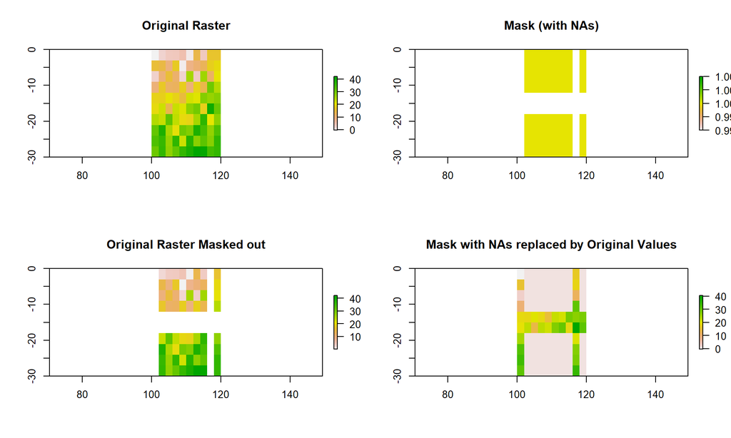

```r
# Substitute the Missing Rows and Columns (i.e. containing NAs) in the Mask, with the Rows # and Columns in the Original Raster to create a Combined Raster.
r2b.coverMaskOrig = cover(r2b.Mask, r2b)


# Plot Original, Mask, Mask Out, and Combined Rasters.
par(mfrow=c(2,2))
plot(r2b, main='Original Raster')
plot(r2b.Mask, main='Mask (with NAs)')
plot(r2b.MaskedOut, main='Original Raster Masked out')
plot(r2b.coverMaskOrig, main='Mask with NAs replaced by Original Values')
```

# 11 Changing the essential Spatial Attributes of a Raster

## 11.1 Changing Spatial Extent

The Spatial Extent of Raster Objects can be modified using several funtions:

### 11.1.1 ‘crop()’

`crop()`: The most commonly used function to modify the extent of a raster object. It returns a geographic subset of an object as specified by an Extent object (or any object from which an extent object can be extracted/created). The Extent object represent our region of interest. When the object to crop is a Raster* object, the Extent is aligned to this object. Areas included in the Extent object, but outside the extent of the object to crop are ignored.

`drawExtent`: Allows to subset a raster object by clicking on two pionts of a plot (raster). Currently, it returns an error when used in Rmarkdown files (used to prepare this tutorial). However, you can give it a try by using the code below. Simply, remove the comment symbol (`#`) in front of the commands containing `drawExtent` or the raster object rb2.crop3.

```r
# It can be used in multiple ways:
r2b
```

```
## class       : RasterLayer
## dimensions  : 10, 10, 100  (nrow, ncol, ncell)
## resolution  : 2, 3  (x, y)
## extent      : 100, 120, -30, 0  (xmin, xmax, ymin, ymax)
## coord. ref. : +proj=longlat +datum=WGS84 +ellps=WGS84 +towgs84=0,0,0
## data source : in memory
## names       : layer
## values      : -0.3952436, 42.14388  (min, max)
```

```r
# Providing the coordinates for the limits of the Extent object
r2b.crop1 = crop(r2b, extent(100,115,-40,-15))
r2b.crop1
```

```
## class       : RasterLayer
## dimensions  : 5, 8, 40  (nrow, ncol, ncell)
## resolution  : 2, 3  (x, y)
## extent      : 100, 116, -30, -15  (xmin, xmax, ymin, ymax)
## coord. ref. : +proj=longlat +datum=WGS84 +ellps=WGS84 +towgs84=0,0,0
## data source : in memory
## names       : layer
## values      : 14.00985, 42.14388  (min, max)
```

```r
# Obtaining the limits of the Extent object from another Spatial Object
# (a Raster, SpatiaPolygon*, SpatialLines*, SpatialPoints* object)
r2c  = raster(nrow=10, ncol=10, xmn=110, xmx=125, ymn=-20, ymx=5)
r2c
```

```
## class       : RasterLayer
## dimensions  : 10, 10, 100  (nrow, ncol, ncell)
## resolution  : 1.5, 2.5  (x, y)
## extent      : 110, 125, -20, 5  (xmin, xmax, ymin, ymax)
## coord. ref. : +proj=longlat +datum=WGS84 +ellps=WGS84 +towgs84=0,0,0
```

```r
r2b.crop2 = crop(r2b, extent(r2c))
r2b.crop2
```

```
## class       : RasterLayer
## dimensions  : 7, 5, 35  (nrow, ncol, ncell)
## resolution  : 2, 3  (x, y)
## extent      : 110, 120, -21, 0  (xmin, xmax, ymin, ymax)
## coord. ref. : +proj=longlat +datum=WGS84 +ellps=WGS84 +towgs84=0,0,0
## data source : in memory
## names       : layer
## values      : 0.4058931, 40.48881  (min, max)
```

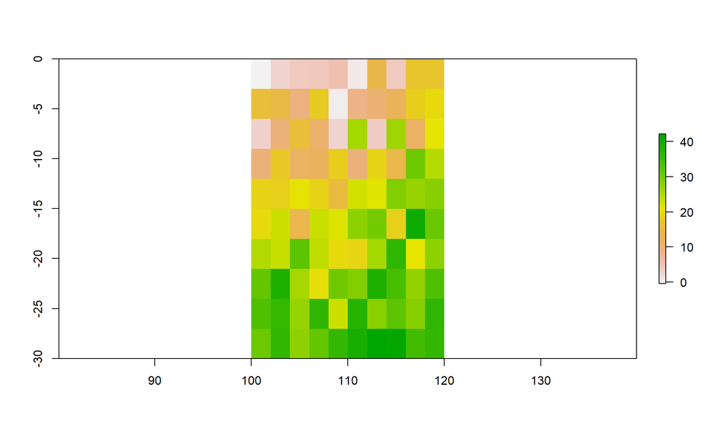

```r
# Plotting the RasterLayer and Manually Drawing  the limits of the Extent object with 'drawExtent()'
# To try it out remove the comment symbol ('#') from the front of the commands below
plot(r2b)
```

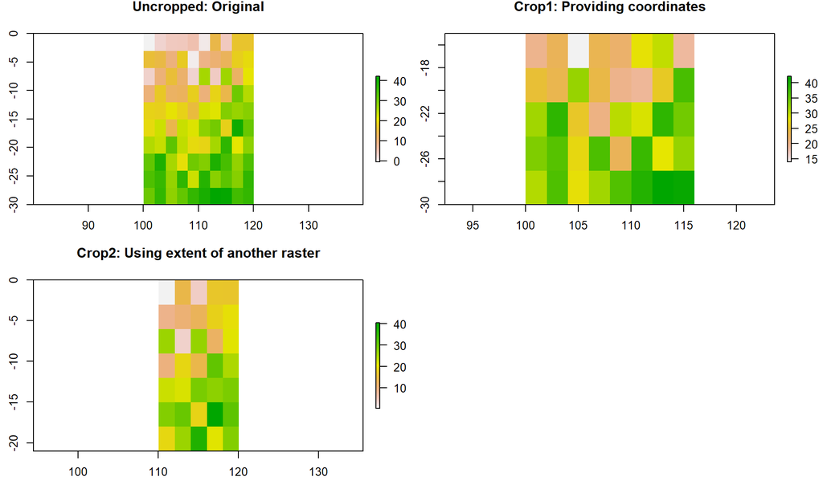

```r
#new.extent = drawExtent()  # To Select the Limits of the new Extent object click twice on the map
#r2b.crop3 = crop(r2b, new.extent)
#r2b.crop3

# Plot Original and 3 Cropped Rasters
par(mfrow=c(2,2))
plot(r2b, main="Uncropped: Original")
plot(r2b.crop1, main="Crop1: Providing coordinates")
plot(r2b.crop2, main="Crop2: Using extent of another raster")
#plot(r2b.crop3, main="Crop3: Cropped interactively")
```

### 11.1.2 ‘merge()’

`merge()`: Merges 2 or more Raster* objects to create a single a new Raster object with a larger (or equal) spatial extent.

The Raster objects must have the same origin and resolution (so their cells neatly fit into a single larger raster). If this is not the case, first adjust one of the Raster objects with use (dis)aggregate or resample (see below).

If objects overlap, the values get priority in the same order as the arguments (i.e. the values of the Raster object that is first in the sequence of arguments will be retained).

NA values are ignored (except when `overlap=FALSE`).

`merge` can directly save the resulting Raster object into a file.

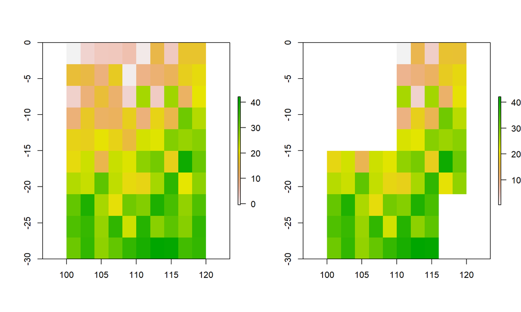

```r
r2b.merge.c1andc2 = merge(r2b.crop1, r2b.crop2)
par(mfrow=c(1,2))
plot(r2b)
plot(r2b.merge.c1andc2)
```

### 11.1.3 ‘trim()’ and ‘extend()’

#### 11.1.3.1 ‘trim()’

Trim (shrink) a Raster* object by removing outer rows and columns that contain the same value (e.g. NA). The multi-layer case is analogous to the single-layer case.

```r
# Single-layer case
# ~~~~~~~~~~~~~~~~

# Create raster and Add NAs
r1a.NAs = r1a
r1a.NAs[1:2,] = NA
r1a.NAs[nrow(r1a.NAs),] = NA

# Trim
r1a.trim = trim(r1a.NAs, values=NA)

# Visualize results
dim(r1a); dim(r1a.NAs); dim(r1a.trim)
```

```
## [1] 10 15  1
```

```
## [1] 10 15  1
```

```
## [1]  7 15  1
```

```r
summary(r1a)[6]; summary(r1a.NAs)[6]; summary(r1a.trim)[6]  # Count of NAs
```

```
## [1] 0
```

```
## [1] 45
```

```
## [1] 0
```

```r
# Multi-layer case
# ~~~~~~~~~~~~~~~~
s1a.NAs = stack(r1a.NAs, r1a.NAs)

# Trim
s1a.trim = trim(s1a.NAs, values=NA)

# Visualize results
dim(s1a); dim(s1a.NAs); dim(s1a.trim)
```

```
## [1] 10 15  2
```

```
## [1] 10 15  2
```

```
## [1]  7 15  2
```

```r
# summary(s1a)[6]; summary(s1a.NAs)[6]; summary(s1a.trim)[6]  # Summary doesn't work for multi-layered objects
```

#### 11.1.3.2 ‘extend()’

Extend returns a Raster* object with a larger spatial extent, by adding new rows and/or columns with a give value (e.g.NA). The output Raster object has the outer minimum and maximum coordinates of the input Raster and Extent arguments. Thus, all of the cells of the original raster are included.

The new extent is provided via the `y` argument. It can be provided in two different ways: * Providing and extent object. This should be a numeric vector of 1, 2, or 4 elements. * Providing an object from which an extent can be extracted * Providing a numeric vector with the number of rows and columns to be added at each side. This vector can have length 2 (i.e.rows and columns) or length 1 if the number of rows and columns is equal.

The argument `value` is used to assign a value to the new cells.

The multi-layer case is analogous to the single-layer case

This function has replaced function “expand” (to avoid a name conflict with the Matrix package).

```r
# Single-layer case
# ~~~~~~~~~~~~~~~~

# This function has replaced function "expand" (to avoid a name conflict with the Matrix package).
r1a
```

```
## class       : RasterLayer
## dimensions  : 10, 15, 150  (nrow, ncol, ncell)
## resolution  : 24, 18  (x, y)
## extent      : -180, 180, -90, 90  (xmin, xmax, ymin, ymax)
## coord. ref. : +proj=longlat +datum=WGS84 +ellps=WGS84 +towgs84=0,0,0
## data source : in memory
## names       : layer
## values      : 1, 1  (min, max)
```

```r
r2a
```

```
## class       : RasterLayer
## dimensions  : 10, 10, 100  (nrow, ncol, ncell)
## resolution  : 2, 3  (x, y)
## extent      : 100, 120, -30, 0  (xmin, xmax, ymin, ymax)
## coord. ref. : +proj=longlat +datum=WGS84 +ellps=WGS84 +towgs84=0,0,0
## data source : in memory
## names       : layer
## values      : 1, 100  (min, max)
```

```r
# Method 1: Providing a new extent object
new.extent = extent(90, 125, -45, 10)
r2a.extended.m1 = extend(r2a, y=new.extent, value=NA)
r2a.extended.m1
```

```
## class       : RasterLayer
## dimensions  : 18, 17, 306  (nrow, ncol, ncell)
## resolution  : 2, 3  (x, y)
## extent      : 90, 124, -45, 9  (xmin, xmax, ymin, ymax)
## coord. ref. : +proj=longlat +datum=WGS84 +ellps=WGS84 +towgs84=0,0,0
## data source : in memory
## names       : layer
## values      : 1, 100  (min, max)
```

```r
# Method 2: Providing an object from which an extent can be extracted
r2a.extended.m2 = extend(r2a, y=r1a, value=NA)
r2a.extended.m2
```

```
## class       : RasterLayer
## dimensions  : 60, 180, 10800  (nrow, ncol, ncell)
## resolution  : 2, 3  (x, y)
## extent      : -180, 180, -90, 90  (xmin, xmax, ymin, ymax)
## coord. ref. : +proj=longlat +datum=WGS84 +ellps=WGS84 +towgs84=0,0,0
## data source : in memory
## names       : layer
## values      : 1, 100  (min, max)
```

```r
# Method 3: Providing a numeric vector with the number of rows and columns to be added at each side.
r2a.extended.m3 = extend(r2a, y=c(3,5), value=NA)
r2a.extended.m3
```

```
## class       : RasterLayer
## dimensions  : 16, 20, 320  (nrow, ncol, ncell)
## resolution  : 2, 3  (x, y)
## extent      : 90, 130, -39, 9  (xmin, xmax, ymin, ymax)
## coord. ref. : +proj=longlat +datum=WGS84 +ellps=WGS84 +towgs84=0,0,0
## data source : in memory
## names       : layer
## values      : 1, 100  (min, max)
```

```r
# Multi-layer case
# ~~~~~~~~~~~~~~~~

# Create multi-layer objects
s1a = stack(r1a, r1a)
s2a = stack(r2a, r2a)

# This function has replaced function "expand" (to avoid a name conflict with the Matrix package).
s1a
```

```
## class       : RasterStack
## dimensions  : 10, 15, 150, 2  (nrow, ncol, ncell, nlayers)
## resolution  : 24, 18  (x, y)
## extent      : -180, 180, -90, 90  (xmin, xmax, ymin, ymax)
## coord. ref. : +proj=longlat +datum=WGS84 +ellps=WGS84 +towgs84=0,0,0
## names       : layer.1, layer.2
## min values  :       1,       1
## max values  :       1,       1
```

```r
s2a
```

```
## class       : RasterStack
## dimensions  : 10, 10, 100, 2  (nrow, ncol, ncell, nlayers)
## resolution  : 2, 3  (x, y)
## extent      : 100, 120, -30, 0  (xmin, xmax, ymin, ymax)
## coord. ref. : +proj=longlat +datum=WGS84 +ellps=WGS84 +towgs84=0,0,0
## names       : layer.1, layer.2
## min values  :       1,       1
## max values  :     100,     100
```

```r
# Method 1: Providing a new extent object
new.extent = extent(90, 125, -45, 10)
s2a.extended.m1 = extend(s2a, y=new.extent, value=NA)
s2a.extended.m1
```

```
## class       : RasterBrick
## dimensions  : 18, 17, 306, 2  (nrow, ncol, ncell, nlayers)
## resolution  : 2, 3  (x, y)
## extent      : 90, 124, -45, 9  (xmin, xmax, ymin, ymax)
## coord. ref. : +proj=longlat +datum=WGS84 +ellps=WGS84 +towgs84=0,0,0
## data source : in memory
## names       : layer.1, layer.2
## min values  :       1,       1
## max values  :     100,     100
```

```r
# Method 2: Providing an object from which an extent can be extracted
s2a.extended.m2 = extend(s2a, y=s1a, value=NA)
s2a.extended.m2
```

```
## class       : RasterBrick
## dimensions  : 60, 180, 10800, 2  (nrow, ncol, ncell, nlayers)
## resolution  : 2, 3  (x, y)
## extent      : -180, 180, -90, 90  (xmin, xmax, ymin, ymax)
## coord. ref. : +proj=longlat +datum=WGS84 +ellps=WGS84 +towgs84=0,0,0
## data source : in memory
## names       : layer.1, layer.2
## min values  :       1,       1
## max values  :     100,     100
```

```r
# Method 3: Providing a numeric vector with the number of rows and columns to be added at each side.
s2a.extended.m3 = extend(s2a, y=c(3,5), value=NA)
s2a.extended.m3
```

```
## class       : RasterBrick
## dimensions  : 16, 20, 320, 2  (nrow, ncol, ncell, nlayers)
## resolution  : 2, 3  (x, y)
## extent      : 90, 130, -39, 9  (xmin, xmax, ymin, ymax)
## coord. ref. : +proj=longlat +datum=WGS84 +ellps=WGS84 +towgs84=0,0,0
## data source : in memory
## names       : layer.1, layer.2
## min values  :       1,       1
## max values  :     100,     100
```

## 11.2 Changing Resolution

### 11.2.1 Changing the Resolution by an Integer Factor (e.g. 2 times smaller)

It can be achieved with the functions: `aggregate` and `disaggregate`.

Changing the Resolution by an Integer Factor is not always possible

#### 11.2.1.1 ‘aggregate()’

`aggregate`: Aggregates a Raster* object to create a new RasterLayer or RasterBrick with a lower resolution (i.e. fewer larger cells). Aggregation groups rectangular areas to create this larger cells. The value for the resulting cells is computed with a user-specified function (e.g. `mean`). Different aggregation functions can be used in the x and y direction.

```r
r2b
```

```
## class       : RasterLayer
## dimensions  : 10, 10, 100  (nrow, ncol, ncell)
## resolution  : 2, 3  (x, y)
## extent      : 100, 120, -30, 0  (xmin, xmax, ymin, ymax)
## coord. ref. : +proj=longlat +datum=WGS84 +ellps=WGS84 +towgs84=0,0,0
## data source : in memory
## names       : layer
## values      : -0.3952436, 42.14388  (min, max)
```

```r
r2b.aggrfactor2 = aggregate(r2b, fact=2, fun=mean)
r2b.aggrfactor2
```

```
## class       : RasterLayer
## dimensions  : 5, 5, 25  (nrow, ncol, ncell)
## resolution  : 4, 6  (x, y)
## extent      : 100, 120, -30, 0  (xmin, xmax, ymin, ymax)
## coord. ref. : +proj=longlat +datum=WGS84 +ellps=WGS84 +towgs84=0,0,0
## data source : in memory
## names       : layer
## values      : 3.634108, 36.0314  (min, max)
```

#### 11.2.1.2 ‘disaggregate()’

`disaggregate`: Does the opposite than ‘aggregate’. It disaggregates a RasterLayer to create a new RasterLayer with a higher resolution (i.e. more smaller cells). The values in the new RasterLayer are the same as in the larger original cells; unless you specify method=“bilinear”, in which case values are locally interpolated (using the resample function).

```r
r2b
```

```
## class       : RasterLayer
## dimensions  : 10, 10, 100  (nrow, ncol, ncell)
## resolution  : 2, 3  (x, y)
## extent      : 100, 120, -30, 0  (xmin, xmax, ymin, ymax)
## coord. ref. : +proj=longlat +datum=WGS84 +ellps=WGS84 +towgs84=0,0,0
## data source : in memory
## names       : layer
## values      : -0.3952436, 42.14388  (min, max)
```

```r
r2b.aggrfactor2
```

```
## class       : RasterLayer
## dimensions  : 5, 5, 25  (nrow, ncol, ncell)
## resolution  : 4, 6  (x, y)
## extent      : 100, 120, -30, 0  (xmin, xmax, ymin, ymax)
## coord. ref. : +proj=longlat +datum=WGS84 +ellps=WGS84 +towgs84=0,0,0
## data source : in memory
## names       : layer
## values      : 3.634108, 36.0314  (min, max)
```

```r
r2b.aggrf2.disaggrf2a = disaggregate(r2b.aggrfactor2, fact=2)  # Cells same values as original
r2b.aggrf2.disaggrf2a
```

```
## class       : RasterLayer
## dimensions  : 10, 10, 100  (nrow, ncol, ncell)
## resolution  : 2, 3  (x, y)
## extent      : 100, 120, -30, 0  (xmin, xmax, ymin, ymax)
## coord. ref. : +proj=longlat +datum=WGS84 +ellps=WGS84 +towgs84=0,0,0
## data source : in memory
## names       : layer
## values      : 3.634108, 36.0314  (min, max)
```

```r
r2b.aggrf2.disaggrf2b = disaggregate(r2b.aggrfactor2, fact=2, method='bilinear')  # Cells with locally interpolated values
r2b.aggrf2.disaggrf2b
```

```
## class       : RasterLayer
## dimensions  : 10, 10, 100  (nrow, ncol, ncell)
## resolution  : 2, 3  (x, y)
## extent      : 100, 120, -30, 0  (xmin, xmax, ymin, ymax)
## coord. ref. : +proj=longlat +datum=WGS84 +ellps=WGS84 +towgs84=0,0,0
## data source : in memory
## names       : layer
## values      : 2.724525, 36.53228  (min, max)
```

Plot original, aggregated, and disaggregated rasters.

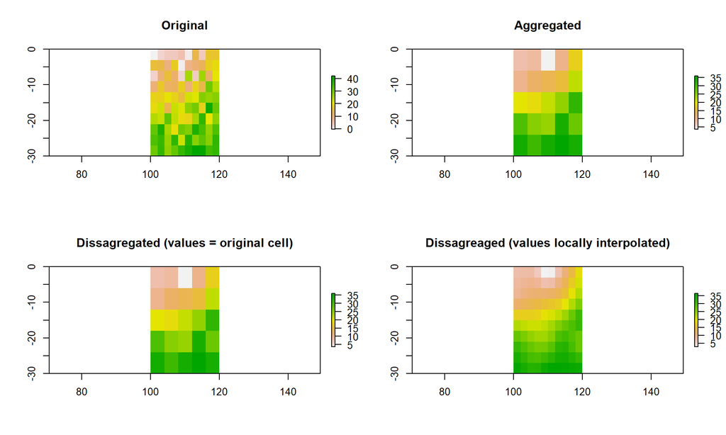

```r
par(mfrow=c(2,2))
plot(r2b, main="Original")
plot(r2b.aggrfactor2, main="Aggregated")
plot(r2b.aggrf2.disaggrf2a, main="Dissagregated (values = original cell)")  # Looks the same as disaggregated cells have the same value than the original cell
plot(r2b.aggrf2.disaggrf2b, main="Dissagreaged (values locally interpolated)")
```